# AI - CA5 - FeedForward NN - Mohammad Farrahi 810198451

### Importing dataset

```python
from google.colab import drive
drive.mount('/content/drive')
import zipfile
zip_ref = zipfile.ZipFile("/content/drive/MyDrive/dataset.zip", 'r')
zip_ref.extractall("/content")
zip_ref.close()
```

### Importing modules

```python
from os import listdir
import numpy as np
import pandas as pd
import tensorboard
import PIL.Image as PilImg
import matplotlib.pyplot as plt
from copy import deepcopy
from tensorflow.keras import *
from tensorflow.keras.utils import *
from sklearn.metrics import classification_report
import warnings
warnings.filterwarnings('ignore')
```

### Hyperparameters

```python
BATCH_SIZE = 32
TARGET_SIZE = (100,100)
VALIDATION_PORTION = 0.25
COLOR_MODE = 'grayscale'
CLASS_MODE = 'categorical'
SHUFFLE = True

EPOCHS = 10
LEARNING_RATE = 0.01
LOSS = 'categorical_crossentropy'
```

## Phase1

### 1-1 & 1-2)

```python
data_gen = preprocessing.image.ImageDataGenerator(
  rescale=1./255,
  validation_split=VALIDATION_PORTION
)

train_data = data_gen.flow_from_directory(
  'dataset/train',
  target_size=TARGET_SIZE,
  color_mode=COLOR_MODE,
  batch_size=BATCH_SIZE,
  class_mode=CLASS_MODE,
  shuffle=SHUFFLE
)
```

```
Found 1945 images belonging to 4 classes.
```

### 1-3)

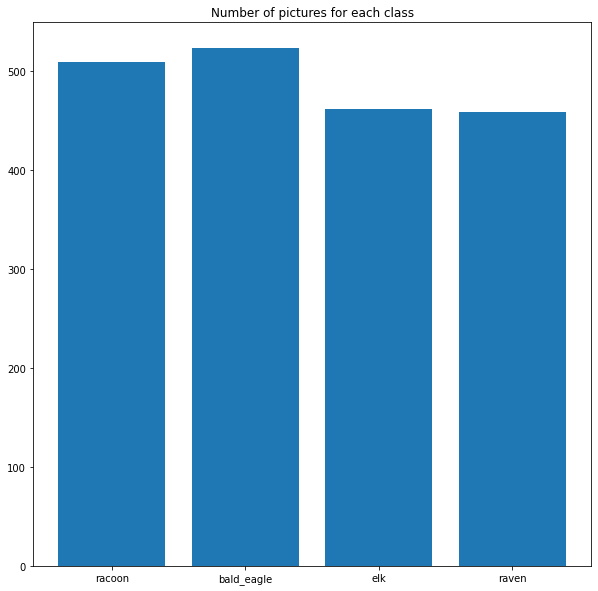

```python
label_classes = listdir('dataset/train')
image_counts = [len(listdir('dataset/train/'+label_class)) for label_class in label_classes]


plt.figure(figsize=(10, 10))
plt.plot()
plt.bar(label_classes, image_counts)
plt.title('Number of pictures for each class')
plt.show()
```

### 1-4)

[figure not shown]

```python
fig, axes = plt.subplots(1, len(label_classes), figsize =(25,25))
for ind, label_class in enumerate(label_classes):
  axes[ind].imshow(np.asarray(PilImg.open('dataset/train/'+label_class+'/'+listdir('dataset/train/'+label_class)[0]).convert(mode='L')) , cmap='gray')
  axes[ind].set_title(label_class)
plt.show()
```

### 1-5 & 1-6)

```python
train_generator = data_gen.flow_from_directory(
  'dataset/train',
  target_size=TARGET_SIZE,
  color_mode=COLOR_MODE,
  batch_size=BATCH_SIZE,
  class_mode=CLASS_MODE,
  subset='training',
  shuffle=SHUFFLE
)
```

```
Found 1461 images belonging to 4 classes.
```

```python
validation_generator = data_gen.flow_from_directory(
  'dataset/train',
  target_size=TARGET_SIZE,
  color_mode=COLOR_MODE,
  batch_size=BATCH_SIZE,
  class_mode=CLASS_MODE,
  subset='validation',
  shuffle=SHUFFLE
)
```

```
Found 484 images belonging to 4 classes.
```

The reason of one-hot encoding for labels is that, our model, as the number of neurons of last layer suggests, estimates the probability of belonging to each of classes for any input; Therefore we need to encode the (true) labels in one-hot way, so we prepare the proper inputs for our loss function that we choose for the model which is _categorical_cross*entropy*. Also in general, one-hot encoding is useful and suggested when there is on order between values of categorical clolumn.

## Phase 2

```python
input = layers.Input(shape=(TARGET_SIZE[0], TARGET_SIZE[1], 1))
output = layers.Flatten()(input)
output = layers.Dense(2048, activation='relu')(output)
output = layers.Dense(1024, activation='relu')(output)
output = layers.Dense(4, activation='softmax')(output)
```

```python
model = models.Model(inputs=input, outputs=output)
model.compile(optimizer=optimizers.SGD(learning_rate=LEARNING_RATE), loss=LOSS, metrics=['accuracy'])
model.summary()
```

```
Model: "model_2"
_________________________________________________________________
 Layer (type)                Output Shape              Param #
=================================================================
 input_3 (InputLayer)        [(None, 100, 100, 1)]     0

 flatten_2 (Flatten)         (None, 10000)             0

 dense_6 (Dense)             (None, 2048)              20482048

 dense_7 (Dense)             (None, 1024)              2098176

 dense_8 (Dense)             (None, 4)                 4100

=================================================================
Total params: 22,584,324
Trainable params: 22,584,324
Non-trainable params: 0
_________________________________________________________________
```

The above table is a summary of our model. we have two hidden layers. In *Param* column we can see the number of parameters for each layer that must be trained. As we understood in previous project (project5-part1) the **weight** matrix for each layer was in shape of #_layer_input*size* *#_layer_output*size*. Also each layer had **bais** vector of size #_layer_output*size*. So the total parameters to be trained is equal to (#_layer_input*size* + 1)* #_layer_output*size*.

In the table above, in first layer for instance we must have : (10000 + 1) * 2048 = 20482048 parameters which we have. For other layers is the same thing.

```python
history = model.fit(train_generator, validation_data=validation_generator, epochs=EPOCHS)
```

```python
train_generator2 = data_gen.flow_from_directory(
  'dataset/train',
  target_size=TARGET_SIZE,
  color_mode=COLOR_MODE,
  batch_size=BATCH_SIZE,
  class_mode=CLASS_MODE,
  subset='training',
  shuffle=False
)

validation_generator2 = data_gen.flow_from_directory(
  'dataset/train',
  target_size=TARGET_SIZE,
  color_mode=COLOR_MODE,
  batch_size=BATCH_SIZE,
  class_mode=CLASS_MODE,
  subset='validation',
  shuffle=False
)

y_train_pred = np.argmax(model.predict(train_generator2), axis=1)
y_train_true = train_generator.classes
y_val_pred = np.argmax(model.predict(validation_generator2), axis=1)
y_val_true = validation_generator.classes
print('Evalution on train data:')
print(classification_report(y_train_true, y_train_pred, target_names=label_classes))
print('Evalution on validation data:')
print(classification_report(y_val_true, y_val_pred, target_names=label_classes))
```

```
Evalution on train data:
              precision    recall  f1-score   support

      racoon       0.94      0.21      0.34       391
  bald_eagle       0.77      0.71      0.74       347
         elk       0.76      0.78      0.77       381
       raven       0.49      0.95      0.64       342

    accuracy                           0.65      1461
   macro avg       0.74      0.66      0.62      1461
weighted avg       0.75      0.65      0.62      1461

Evalution on validation data:
              precision    recall  f1-score   support

      racoon       0.85      0.17      0.28       130
  bald_eagle       0.67      0.64      0.66       115
         elk       0.64      0.66      0.65       126
       raven       0.45      0.88      0.60       113

    accuracy                           0.57       484
   macro avg       0.65      0.59      0.55       484
weighted avg       0.66      0.57      0.54       484
```

## Phase 3

After So many trial and error, I concluded that this is the best configure for model.

```python
input = layers.Input(shape=(TARGET_SIZE[0], TARGET_SIZE[1], 1))
output = layers.Flatten()(input)
output = layers.Dense(4096, activation='relu')(output)
output = layers.Dense(1024, activation='relu')(output)
output = layers.Dense(4, activation='softmax')(output)
```

```python
model = models.Model(inputs=input, outputs=output)
model.compile(optimizer=optimizers.SGD(learning_rate=LEARNING_RATE), loss=LOSS, metrics=['accuracy'])
model.summary()
```

```
Model: "model_12"
_________________________________________________________________
 Layer (type)                Output Shape              Param #
=================================================================
 input_9 (InputLayer)        [(None, 100, 100, 1)]     0

 flatten_8 (Flatten)         (None, 10000)             0

 dense_26 (Dense)            (None, 4096)              40964096

 dense_27 (Dense)            (None, 1024)              4195328

 dense_28 (Dense)            (None, 4)                 4100

=================================================================
Total params: 45,163,524
Trainable params: 45,163,524
Non-trainable params: 0
_________________________________________________________________
```

```python
history = model.fit(train_generator, validation_data=validation_generator, epochs=EPOCHS)
```

```python
train_generator2 = data_gen.flow_from_directory(
  'dataset/train',
  target_size=TARGET_SIZE,
  color_mode=COLOR_MODE,
  batch_size=BATCH_SIZE,
  class_mode=CLASS_MODE,
  subset='training',
  shuffle=False
)

validation_generator2 = data_gen.flow_from_directory(
  'dataset/train',
  target_size=TARGET_SIZE,
  color_mode=COLOR_MODE,
  batch_size=BATCH_SIZE,
  class_mode=CLASS_MODE,
  subset='validation',
  shuffle=False
)
y_train_pred = np.argmax(model.predict(train_generator2), axis=1)
y_train_true = train_generator.classes
y_val_pred = np.argmax(model.predict(validation_generator2), axis=1)
y_val_true = validation_generator.classes
print('Evalution on train data:')
print(classification_report(y_train_true, y_train_pred, target_names=label_classes))
print('Evalution on validation data:')
print(classification_report(y_val_true, y_val_pred, target_names=label_classes))
```

```
Found 1461 images belonging to 4 classes.
Found 484 images belonging to 4 classes.
Evalution on train data:
              precision    recall  f1-score   support

      racoon       0.69      0.78      0.73       391
  bald_eagle       0.64      0.93      0.76       347
         elk       0.93      0.66      0.77       381
       raven       0.87      0.63      0.73       342

    accuracy                           0.75      1461
   macro avg       0.78      0.75      0.75      1461
weighted avg       0.78      0.75      0.75      1461

Evalution on validation data:
              precision    recall  f1-score   support

      racoon       0.60      0.72      0.65       130
  bald_eagle       0.59      0.86      0.70       115
         elk       0.76      0.52      0.62       126
       raven       0.80      0.52      0.63       113

    accuracy                           0.65       484
   macro avg       0.69      0.66      0.65       484
weighted avg       0.68      0.65      0.65       484
```

### 3-1) Optimizer impact

Momentum is some kind of ‘moving’ average which would ‘denoise’ the data and bring it closer to the original function. This average is called exponentially weighed average.

With Stochastic Gradient Descent we don’t compute the exact derivate of our loss function. Instead, we’re estimating it on a small batch. Which means we’re not always going in the optimal direction, because our derivatives are ‘noisy’. So, exponentially weighed averages can provide us a better estimate which is closer to the actual derivate than our noisy calculations. This is one reason why momentum might work better than classic SGD.

The other reason lies in ravines. Ravine is an area, where the surface curves much more steeply in one dimension than in another. Ravines are common near local minimas in deep learning and SGD has troubles navigating them. SGD will tend to oscillate across the narrow ravine since the negative gradient will point down one of the steep sides rather than along the ravine towards the optimum. Momentum helps accelerate gradients in the right direction

#### Mumentum = 0.5

```python
model1 = models.Model(inputs=input, outputs=output)
model1.compile(optimizer=optimizers.SGD(learning_rate=LEARNING_RATE, momentum=0.5), loss=LOSS, metrics=['accuracy'])
```

```python
print("with momentum=0.5: ")
history = model1.fit(train_generator, validation_data=validation_generator, epochs=EPOCHS)
```

```
with momentum=0.5:
```

#### Evaluation

```python
train_generator2 = data_gen.flow_from_directory(
  'dataset/train',
  target_size=TARGET_SIZE,
  color_mode=COLOR_MODE,
  batch_size=BATCH_SIZE,
  class_mode=CLASS_MODE,
  subset='training',
  shuffle=False
)

validation_generator2 = data_gen.flow_from_directory(
  'dataset/train',
  target_size=TARGET_SIZE,
  color_mode=COLOR_MODE,
  batch_size=BATCH_SIZE,
  class_mode=CLASS_MODE,
  subset='validation',
  shuffle=False
)
y_train_pred = np.argmax(model1.predict(train_generator2), axis=1)
y_train_true = train_generator.classes
y_val_pred = np.argmax(model1.predict(validation_generator2), axis=1)
y_val_true = validation_generator.classes
print('Evalution on train data:')
print(classification_report(y_train_true, y_train_pred, target_names=label_classes))
print('Evalution on validation data:')
print(classification_report(y_val_true, y_val_pred, target_names=label_classes))
```

```
Found 1461 images belonging to 4 classes.
Found 484 images belonging to 4 classes.
Evalution on train data:
              precision    recall  f1-score   support

      racoon       0.96      0.59      0.73       391
  bald_eagle       0.52      0.99      0.68       347
         elk       1.00      0.61      0.76       381
       raven       0.89      0.84      0.87       342

    accuracy                           0.75      1461
   macro avg       0.84      0.76      0.76      1461
weighted avg       0.85      0.75      0.76      1461

Evalution on validation data:
              precision    recall  f1-score   support

      racoon       0.80      0.41      0.54       130
  bald_eagle       0.43      0.95      0.59       115
         elk       0.89      0.43      0.58       126
       raven       0.70      0.64      0.67       113

    accuracy                           0.60       484
   macro avg       0.70      0.61      0.59       484
weighted avg       0.71      0.60      0.59       484
```

#### Mumentum = 0.9

```python
model2 = models.Model(inputs=input, outputs=output)
model2.compile(optimizer=optimizers.SGD(learning_rate=LEARNING_RATE, momentum=0.9), loss=LOSS, metrics=['accuracy'])
```

```python
print("with momentum=0.9: ")
history = model2.fit(train_generator, validation_data=validation_generator, epochs=EPOCHS)
```

```
with momentum=0.9:
```

#### Evaluation

```python
train_generator2 = data_gen.flow_from_directory(
  'dataset/train',
  target_size=TARGET_SIZE,
  color_mode=COLOR_MODE,
  batch_size=BATCH_SIZE,
  class_mode=CLASS_MODE,
  subset='training',
  shuffle=False
)

validation_generator2 = data_gen.flow_from_directory(
  'dataset/train',
  target_size=TARGET_SIZE,
  color_mode=COLOR_MODE,
  batch_size=BATCH_SIZE,
  class_mode=CLASS_MODE,
  subset='validation',
  shuffle=False
)
y_train_pred = np.argmax(model2.predict(train_generator2), axis=1)
y_train_true = train_generator.classes
y_val_pred = np.argmax(model2.predict(validation_generator2), axis=1)
y_val_true = validation_generator.classes
print('Evalution on train data:')
print(classification_report(y_train_true, y_train_pred, target_names=label_classes))
print('Evalution on validation data:')
print(classification_report(y_val_true, y_val_pred, target_names=label_classes))
```

```
Found 1461 images belonging to 4 classes.
Found 484 images belonging to 4 classes.
Evalution on train data:
              precision    recall  f1-score   support

      racoon       0.73      0.72      0.73       391
  bald_eagle       0.80      0.81      0.81       347
         elk       0.71      0.94      0.81       381
       raven       0.90      0.58      0.71       342

    accuracy                           0.77      1461
   macro avg       0.79      0.77      0.76      1461
weighted avg       0.78      0.77      0.76      1461

Evalution on validation data:
              precision    recall  f1-score   support

      racoon       0.61      0.56      0.58       130
  bald_eagle       0.66      0.62      0.64       115
         elk       0.55      0.83      0.66       126
       raven       0.76      0.44      0.56       113

    accuracy                           0.62       484
   macro avg       0.64      0.61      0.61       484
weighted avg       0.64      0.62      0.61       484
```

Increasing momentum hyperparameter, doesn't always help to get better results. When you are increasing moemntum, you average over larger number of examples, since momentum is kind of moving exponentially weighted average. So training will be slow; Also averaging from large number of previous gradients may not be suitable, because that much history of gradients Participating in calculating current gradient is not necessary.

#### Adam optimizer

```python
model = models.Model(inputs=input, outputs=output)
model.compile(optimizer=optimizers.Adam(), loss=LOSS, metrics=['accuracy'])
history = model.fit(train_generator, validation_data=validation_generator, epochs=EPOCHS)
```

```python
train_generator2 = data_gen.flow_from_directory(
  'dataset/train',
  target_size=TARGET_SIZE,
  color_mode=COLOR_MODE,
  batch_size=BATCH_SIZE,
  class_mode=CLASS_MODE,
  subset='training',
  shuffle=False
)

validation_generator2 = data_gen.flow_from_directory(
  'dataset/train',
  target_size=TARGET_SIZE,
  color_mode=COLOR_MODE,
  batch_size=BATCH_SIZE,
  class_mode=CLASS_MODE,
  subset='validation',
  shuffle=False
)
y_train_pred = np.argmax(model.predict(train_generator2), axis=1)
y_train_true = train_generator.classes
y_val_pred = np.argmax(model.predict(validation_generator2), axis=1)
y_val_true = validation_generator.classes
print('Evalution on train data:')
print(classification_report(y_train_true, y_train_pred, target_names=label_classes))
print('Evalution on validation data:')
print(classification_report(y_val_true, y_val_pred, target_names=label_classes))
```

```
Found 1461 images belonging to 4 classes.
Found 484 images belonging to 4 classes.
Evalution on train data:
              precision    recall  f1-score   support

      racoon       0.73      0.48      0.58       391
  bald_eagle       0.97      0.53      0.68       347
         elk       0.75      0.91      0.82       381
       raven       0.56      0.92      0.70       342

    accuracy                           0.70      1461
   macro avg       0.75      0.71      0.70      1461
weighted avg       0.75      0.70      0.69      1461

Evalution on validation data:
              precision    recall  f1-score   support

      racoon       0.60      0.42      0.50       130
  bald_eagle       0.74      0.35      0.47       115
         elk       0.63      0.75      0.69       126
       raven       0.50      0.83      0.62       113

    accuracy                           0.59       484
   macro avg       0.62      0.59      0.57       484
weighted avg       0.62      0.59      0.57       484
```

As the results of metrics measures in evalution part shows, we get more optimized model, when we use *SGD with momentum* optimizer than Adam optimizer.

macro avg f1 on validation data : Adam = 0.57 | SGD(momentum=0.9) = 0.61

### 3-2) Epochs impact

Generally whenever we want to optimize, we use gradient descent. Gradient descent has a parameter called learning rate. In one iteration alone we can not guarantee that the gradient descent algorithm would converge to a local minima with the specified learning rate. That is the reason why we use multiple epochs and iterate again for the gradient descent to converge better.

Usually in problems that we need a iterative approaches and algorithms to solve the problem and get optimal solution, we may need to multiple epochs.

```python
EPOCHS = 20
model = models.Model(inputs=input, outputs=output)
model.compile(optimizer=optimizers.Adam(), loss=LOSS, metrics=['accuracy'])
history = model.fit(train_generator, validation_data=validation_generator, epochs=EPOCHS)
```

```python
train_generator2 = data_gen.flow_from_directory(
  'dataset/train',
  target_size=TARGET_SIZE,
  color_mode=COLOR_MODE,
  batch_size=BATCH_SIZE,
  class_mode=CLASS_MODE,
  subset='training',
  shuffle=False
)

validation_generator2 = data_gen.flow_from_directory(
  'dataset/train',
  target_size=TARGET_SIZE,
  color_mode=COLOR_MODE,
  batch_size=BATCH_SIZE,
  class_mode=CLASS_MODE,
  subset='validation',
  shuffle=False
)
y_train_pred = np.argmax(model.predict(train_generator2), axis=1)
y_train_true = train_generator.classes
y_val_pred = np.argmax(model.predict(validation_generator2), axis=1)
y_val_true = validation_generator.classes
print('Evalution on train data:')
print(classification_report(y_train_true, y_train_pred, target_names=label_classes))
print('Evalution on validation data:')
print(classification_report(y_val_true, y_val_pred, target_names=label_classes))
```

```
Found 1461 images belonging to 4 classes.
Found 484 images belonging to 4 classes.
Evalution on train data:
              precision    recall  f1-score   support

      racoon       0.69      0.72      0.71       391
  bald_eagle       0.73      0.97      0.84       347
         elk       0.92      0.96      0.94       381
       raven       0.99      0.57      0.73       342

    accuracy                           0.81      1461
   macro avg       0.83      0.81      0.80      1461
weighted avg       0.83      0.81      0.80      1461

Evalution on validation data:
              precision    recall  f1-score   support

      racoon       0.58      0.62      0.60       130
  bald_eagle       0.57      0.81      0.67       115
         elk       0.72      0.76      0.74       126
       raven       0.87      0.36      0.51       113

    accuracy                           0.64       484
   macro avg       0.68      0.64      0.63       484
weighted avg       0.68      0.64      0.63       484
```

#### Ploting loss and accuracy

```
Plot of accrucy and loss for train and validation data for different epochs :
```

[figure not shown]

```python
print('Plot of accrucy and loss for train and validation data for different epochs :')
plt.figure(figsize=(15, 10))
axe = plt.subplot(2,2,1)
axe.plot(np.arange(1,21), history.history['accuracy'])
axe.set_title('Train - Accuracy')
axe.set(xlabel='epoch', ylabel='accuracy')

axe = plt.subplot(2,2,2)
axe.plot(np.arange(1,21), history.history['loss'])
axe.set_title('Train - Loss')
axe.set(xlabel='epoch', ylabel='loss')

axe = plt.subplot(2,2,3)
axe.plot(np.arange(1,21), history.history['val_accuracy'])
axe.set_title('Validation - Accuracy')
axe.set(xlabel='epoch', ylabel='accuracy')

axe = plt.subplot(2,2,4)
axe.plot(np.arange(1,21), history.history['accuracy'])
axe.set_title('Validation - Loss')
axe.set(xlabel='epoch', ylabel='val_loss')

plt.show()
```

```python
earlystopping = callbacks.EarlyStopping(monitor ="val_accuracy",
                                        mode ="max", patience = 8,
                                        restore_best_weights = True)

model = models.Model(inputs=input, outputs=output)
model.compile(optimizer=optimizers.Adam(), loss=LOSS, metrics=['accuracy'])
history = model.fit(train_generator, validation_data=validation_generator, epochs=EPOCHS, callbacks=[earlystopping])
```

```python
train_generator2 = data_gen.flow_from_directory(
  'dataset/train',
  target_size=TARGET_SIZE,
  color_mode=COLOR_MODE,
  batch_size=BATCH_SIZE,
  class_mode=CLASS_MODE,
  subset='training',
  shuffle=False
)

validation_generator2 = data_gen.flow_from_directory(
  'dataset/train',
  target_size=TARGET_SIZE,
  color_mode=COLOR_MODE,
  batch_size=BATCH_SIZE,
  class_mode=CLASS_MODE,
  subset='validation',
  shuffle=False
)
y_train_pred = np.argmax(model.predict(train_generator2), axis=1)
y_train_true = train_generator.classes
y_val_pred = np.argmax(model.predict(validation_generator2), axis=1)
y_val_true = validation_generator.classes
print('Evalution on train data:')
print(classification_report(y_train_true, y_train_pred, target_names=label_classes))
print('Evalution on validation data:')
print(classification_report(y_val_true, y_val_pred, target_names=label_classes))
```

```
Found 1461 images belonging to 4 classes.
Found 484 images belonging to 4 classes.
Evalution on train data:
              precision    recall  f1-score   support

      racoon       0.90      0.98      0.94       391
  bald_eagle       0.95      0.98      0.97       347
         elk       1.00      0.97      0.98       381
       raven       0.99      0.90      0.94       342

    accuracy                           0.96      1461
   macro avg       0.96      0.96      0.96      1461
weighted avg       0.96      0.96      0.96      1461

Evalution on validation data:
              precision    recall  f1-score   support

      racoon       0.67      0.78      0.72       130
  bald_eagle       0.69      0.76      0.72       115
         elk       0.90      0.79      0.84       126
       raven       0.81      0.68      0.74       113

    accuracy                           0.75       484
   macro avg       0.77      0.75      0.76       484
weighted avg       0.77      0.75      0.76       484
```

Using too much epochs, may cause the model, become train-data-specific or in ohther word, it may cause **overfitting** in model. So too many epochs in not good, To avoid this, we can use tril and error method to find suitable number of epochs or we can use *EarlyStopping* callback mechanism of tf.keras. This function is passed to *fit* method of model, when training, and aviod continuting training when overfitting is happening. This is exactly what we have used in above section to evoid overfitting and as you can see, we end up to a better macro avg f1 for validation data which is 76%

### 3-3) Loss fucntion impact

```python
LOSS = 'mean_squared_error'
earlystopping = callbacks.EarlyStopping(monitor ="val_accuracy",
                                        mode ="max", patience = 2,
                                        restore_best_weights = True)
model_mse = models.Model(inputs=input, outputs=output)
model_mse.compile(optimizer=optimizers.Adam(), loss=LOSS, metrics=['accuracy'])
history_mse = model_mse.fit(train_generator, validation_data=validation_generator, epochs=EPOCHS, callbacks=[earlystopping])
```

```python
train_generator2 = data_gen.flow_from_directory(
  'dataset/train',
  target_size=TARGET_SIZE,
  color_mode=COLOR_MODE,
  batch_size=BATCH_SIZE,
  class_mode=CLASS_MODE,
  subset='training',
  shuffle=False
)

validation_generator2 = data_gen.flow_from_directory(
  'dataset/train',
  target_size=TARGET_SIZE,
  color_mode=COLOR_MODE,
  batch_size=BATCH_SIZE,
  class_mode=CLASS_MODE,
  subset='validation',
  shuffle=False
)
y_train_pred = np.argmax(model_mse.predict(train_generator2), axis=1)
y_train_true = train_generator.classes
y_val_pred = np.argmax(model_mse.predict(validation_generator2), axis=1)
y_val_true = validation_generator.classes
print('Evalution on train data:')
print(classification_report(y_train_true, y_train_pred, target_names=label_classes))
print('Evalution on validation data:')
print(classification_report(y_val_true, y_val_pred, target_names=label_classes))
```

```
Found 1461 images belonging to 4 classes.
Found 484 images belonging to 4 classes.
Evalution on train data:
              precision    recall  f1-score   support

      racoon       0.93      0.98      0.96       391
  bald_eagle       0.99      0.97      0.98       347
         elk       1.00      0.99      0.99       381
       raven       0.98      0.95      0.96       342

    accuracy                           0.97      1461
   macro avg       0.97      0.97      0.97      1461
weighted avg       0.97      0.97      0.97      1461

Evalution on validation data:
              precision    recall  f1-score   support

      racoon       0.69      0.75      0.72       130
  bald_eagle       0.76      0.74      0.75       115
         elk       0.82      0.77      0.80       126
       raven       0.75      0.73      0.74       113

    accuracy                           0.75       484
   macro avg       0.75      0.75      0.75       484
weighted avg       0.75      0.75      0.75       484
```

In the obove, we trained a model with loss of *MSE*, and as shown in metrics measure table, the macro avg f1 is lower than when we used _categorical_cross*enctropy*

The choice of cost function is tightly coupled with the choice of output unit. The choice of how to represent the output then determines the form of the loss function.

In Multi-Class Classification Problems such as our problem, the problem is framed as predicting the likelihood of an example belonging to each class. as we chose last layer to have 4 neurons with *softmax* activation function, each outputs probabily of belongining to a specific class. So _categorical_cross*entropy* loss is suitable because this function is used to measure loss and cost between two probabilty distributions.

Where *MSE* is mostly used in Regression Problems. In this case, output layer has one node with *linear* activation function, outputing predicted real value.

### 3-4) Regularization impact

#### L2

```python
input_regu = layers.Input(shape=(TARGET_SIZE[0], TARGET_SIZE[1], 1))
output_regu = layers.Flatten()(input_regu)
output_regu = layers.Dense(4096, activation='relu', kernel_regularizer=regularizers.l2(1e-4), bias_regularizer=regularizers.l2(1e-4))(output_regu)
output_regu = layers.Dense(1024, activation='relu', kernel_regularizer=regularizers.l2(1e-4), bias_regularizer=regularizers.l2(1e-4))(output_regu)
output_regu = layers.Dense(4, activation='softmax', kernel_regularizer=regularizers.l2(1e-4), bias_regularizer=regularizers.l2(1e-4))(output_regu)

LOSS = 'categorical_crossentropy'
earlystopping = callbacks.EarlyStopping(monitor ="val_accuracy",
                                        mode ="max", patience = 7,
                                        restore_best_weights = True)
model_regu = models.Model(inputs=input_regu, outputs=output_regu)
model_regu.compile(optimizer=optimizers.Adam(), loss=LOSS, metrics=['accuracy'])
history_regu = model_regu.fit(train_generator, validation_data=validation_generator, epochs=EPOCHS, callbacks=[earlystopping])
```

```python
train_generator2 = data_gen.flow_from_directory(
  'dataset/train',
  target_size=TARGET_SIZE,
  color_mode=COLOR_MODE,
  batch_size=BATCH_SIZE,
  class_mode=CLASS_MODE,
  subset='training',
  shuffle=False
)

validation_generator2 = data_gen.flow_from_directory(
  'dataset/train',
  target_size=TARGET_SIZE,
  color_mode=COLOR_MODE,
  batch_size=BATCH_SIZE,
  class_mode=CLASS_MODE,
  subset='validation',
  shuffle=False
)
y_train_pred = np.argmax(model_regu.predict(train_generator2), axis=1)
y_train_true = train_generator.classes
y_val_pred = np.argmax(model_regu.predict(validation_generator2), axis=1)
y_val_true = validation_generator.classes
print('Evalution on train data:')
print(classification_report(y_train_true, y_train_pred, target_names=label_classes))
print('Evalution on validation data:')
print(classification_report(y_val_true, y_val_pred, target_names=label_classes))
```

```
Found 1461 images belonging to 4 classes.
Found 484 images belonging to 4 classes.
Evalution on train data:
              precision    recall  f1-score   support

      racoon       0.89      0.68      0.77       391
  bald_eagle       0.97      0.90      0.93       347
         elk       1.00      0.82      0.90       381
       raven       0.63      0.98      0.77       342

    accuracy                           0.84      1461
   macro avg       0.87      0.84      0.84      1461
weighted avg       0.88      0.84      0.84      1461

Evalution on validation data:
              precision    recall  f1-score   support

      racoon       0.69      0.48      0.56       130
  bald_eagle       0.82      0.72      0.77       115
         elk       0.86      0.67      0.76       126
       raven       0.51      0.88      0.64       113

    accuracy                           0.68       484
   macro avg       0.72      0.69      0.68       484
weighted avg       0.72      0.68      0.68       484
```

Generally we shall get a better result with regularization; But our case, we don't :) . Regularization hasn't help to get better macro avg f1 or accuracy in validation data as metrics measure table above, shows.

#### Dropout

```python
input_regu = layers.Input(shape=(TARGET_SIZE[0], TARGET_SIZE[1], 1))
output_regu = layers.Flatten()(input_regu)
output_regu = layers.Dense(4096, activation='relu')(output_regu)
output_regu = layers.Dropout(0.1)(output_regu)
output_regu = layers.Dense(1024, activation='relu')(output_regu)
output_regu = layers.Dropout(0.1)(output_regu)
output_regu = layers.Dense(4, activation='softmax')(output_regu)

LOSS = 'categorical_crossentropy'
earlystopping = callbacks.EarlyStopping(monitor ="val_accuracy",
                                        mode ="max", patience = 7,
                                        restore_best_weights = True)
model_regu = models.Model(inputs=input_regu, outputs=output_regu)
model_regu.compile(optimizer=optimizers.Adam(), loss=LOSS, metrics=['accuracy'])
model_regu.summary()
```

```
Model: "model_25"
_________________________________________________________________
 Layer (type)                Output Shape              Param #
=================================================================
 input_12 (InputLayer)       [(None, 100, 100, 1)]     0

 flatten_11 (Flatten)        (None, 10000)             0

 dense_35 (Dense)            (None, 4096)              40964096

 dropout (Dropout)           (None, 4096)              0

 dense_36 (Dense)            (None, 1024)              4195328

 dropout_1 (Dropout)         (None, 1024)              0

 dense_37 (Dense)            (None, 4)                 4100

=================================================================
Total params: 45,163,524
Trainable params: 45,163,524
Non-trainable params: 0
_________________________________________________________________
```

```python
history_regu = model_regu.fit(train_generator, validation_data=validation_generator, epochs=EPOCHS, callbacks=[earlystopping])
```

```python
train_generator2 = data_gen.flow_from_directory(
  'dataset/train',
  target_size=TARGET_SIZE,
  color_mode=COLOR_MODE,
  batch_size=BATCH_SIZE,
  class_mode=CLASS_MODE,
  subset='training',
  shuffle=False
)

validation_generator2 = data_gen.flow_from_directory(
  'dataset/train',
  target_size=TARGET_SIZE,
  color_mode=COLOR_MODE,
  batch_size=BATCH_SIZE,
  class_mode=CLASS_MODE,
  subset='validation',
  shuffle=False
)
y_train_pred = np.argmax(model_regu.predict(train_generator2), axis=1)
y_train_true = train_generator.classes
y_val_pred = np.argmax(model_regu.predict(validation_generator2), axis=1)
y_val_true = validation_generator.classes
print('Evalution on train data:')
print(classification_report(y_train_true, y_train_pred, target_names=label_classes))
print('Evalution on validation data:')
print(classification_report(y_val_true, y_val_pred, target_names=label_classes))
```

```
Found 1461 images belonging to 4 classes.
Found 484 images belonging to 4 classes.
Evalution on train data:
              precision    recall  f1-score   support

      racoon       0.50      0.94      0.66       391
  bald_eagle       0.91      0.56      0.70       347
         elk       0.87      0.67      0.75       381
       raven       0.87      0.57      0.69       342

    accuracy                           0.69      1461
   macro avg       0.79      0.69      0.70      1461
weighted avg       0.78      0.69      0.70      1461

Evalution on validation data:
              precision    recall  f1-score   support

      racoon       0.42      0.88      0.57       130
  bald_eagle       0.72      0.37      0.49       115
         elk       0.70      0.52      0.59       126
       raven       0.79      0.42      0.55       113

    accuracy                           0.56       484
   macro avg       0.66      0.55      0.55       484
weighted avg       0.65      0.56      0.55       484
```

we can see that dropout regularization isn't helping neither

## Predict Test Data

### Final Model

```python
input = layers.Input(shape=(TARGET_SIZE[0], TARGET_SIZE[1], 1))
output = layers.Flatten()(input)
output = layers.Dense(4096, activation='relu')(output)
output = layers.Dense(1024, activation='relu')(output)
output = layers.Dense(4, activation='softmax')(output)


EPOCHS = 20
LOSS = 'categorical_crossentropy'
earlystopping = callbacks.EarlyStopping(monitor ="val_accuracy",
                                        mode ="max", patience = 8,
                                        restore_best_weights = True)

modelF = models.Model(inputs=input, outputs=output)
modelF.compile(optimizer=optimizers.Adam(), loss=LOSS, metrics=['accuracy'])
```

#### Training

```python
historyF = modelF.fit(train_generator, validation_data=validation_generator, epochs=EPOCHS, callbacks=[earlystopping])
```

#### Evaluation

```python
test_gen = preprocessing.image.ImageDataGenerator(
  rescale=1./255,
)

test_data = test_gen.flow_from_directory(
  'dataset/test',
  target_size=TARGET_SIZE,
  color_mode=COLOR_MODE,
  batch_size=BATCH_SIZE,
  class_mode=CLASS_MODE,
  shuffle=False
)
y_test_pred = np.argmax(modelF.predict(test_data), axis=1)
y_test_true = test_data.classes

print('Evalution on test data:')
print(classification_report(y_test_true, y_test_pred, target_names=label_classes))
```

```
Found 833 images belonging to 4 classes.
Evalution on test data:
              precision    recall  f1-score   support

      racoon       0.51      0.70      0.59       223
  bald_eagle       0.67      0.79      0.72       198
         elk       0.77      0.63      0.69       217
       raven       0.74      0.43      0.54       195

    accuracy                           0.64       833
   macro avg       0.67      0.64      0.64       833
weighted avg       0.67      0.64      0.64       833
```

```python
np.random.randint(0, 4, 1)[0]
```

```
1
```

```
Truely predicted pictures:
```

[figure not shown]

```python
visited_indexes = []
count = 0
code_to_label_m = {code:label for label,code in test_data.class_indices.items()}

print('Truely predicted pictures: ')
plt.figure(figsize=(40,20))
while(count < 10):
  random_ind = np.random.randint(0, len(test_data.classes), 1)[0]
  if(y_test_pred[random_ind] != y_test_true[random_ind] or random_ind in visited_indexes):
    continue
  visited_indexes.append(random_ind)
  plt.subplot(2,5, count+1)
  img = PilImg.open('dataset/test/'+test_data.filenames[random_ind])
  img.thumbnail(TARGET_SIZE)
  plt.imshow(img)
  plt.title('y_true: ' + code_to_label_m[y_test_true[random_ind]] + ', y_pred: ' + code_to_label_m[y_test_pred[random_ind]])
  count += 1
```

```
Falsely predicted pictures:
```

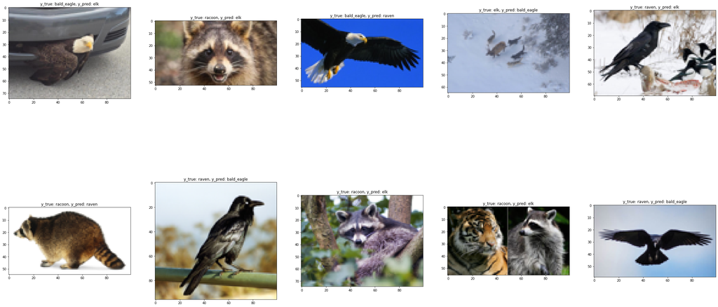

```python
count = 0
print('Falsely predicted pictures: ')
plt.figure(figsize=(40,20))
while(count < 10):
  random_ind = np.random.randint(0, len(test_data.classes), 1)[0]
  if(y_test_pred[random_ind] == y_test_true[random_ind] or random_ind in visited_indexes):
    continue
  visited_indexes.append(random_ind)
  plt.subplot(2,5,count + 1)
  img = PilImg.open('dataset/test/'+test_data.filenames[random_ind])
  img.thumbnail(TARGET_SIZE)
  plt.imshow(img)
  plt.title('y_true: ' + code_to_label_m[y_test_true[random_ind]] + ', y_pred: ' + code_to_label_m[y_test_pred[random_ind]])
  count += 1
```

The reason of such a misprediction may be that the background of mispredicted picture is mostly used in false-predicted class. For example the second picture of first row is look like a background of a elk picture.

Also we can see that raven and bald_eagle pictures are commonly misclassified interchangeably, which is kind of reasonable.